# R Notebook

```r
library(haven)
bagdad_london_finalRestat <- read_dta("~/R_course/lession4/Bosker_Data/bagdad-london--finalRestat.dta")
min(bagdad_london_finalRestat$year)
```

```
[1] 800
```

```r
max(bagdad_london_finalRestat$year)
```

```
[1] 1800
```

```r
summary(bagdad_london_finalRestat$year)
```

```
   Min. 1st Qu.  Median    Mean 3rd Qu.    Max.
    800    1000    1300    1300    1600    1800
```

```r
#What periods can it be divided into? How can we do that?
Medieval.bagdad.sub <- subset(bagdad_london_finalRestat,  bagdad_london_finalRestat$year <= 1500)
Medieval.bagdad.sub
```

| indicator | city | country | year | arab_peninsula | latitude | longitude | citypop_le10 | citypop_le5 | sea | river | hub_3rr | rom_road_nohub | caravan_hub | caravan_nohub | elevation_m | rugg10 | bishop | archbishop | capital | university | muslim | me_na | muslim_holy_city | plundered | soilquality | commune | ecozones | free_prince_dls | total_pop_country | … |
| --- | --- | --- | --- | --- | --- | --- | --- | --- | --- | --- | --- | --- | --- | --- | --- | --- | --- | --- | --- | --- | --- | --- | --- | --- | --- | --- | --- | --- | --- | --- |
| 1 | Graz | Austria | 800 | 0 | 47.067 | 15.450 | 0 | 0 | 0 | 1 | 0 | 1 | 0 | 0 | 366 | 103.62000 | 0 | 0 | 0 | 0 | 0 | 0 | 0 | 0 | 0.4140000 | 0 | 6 | 0 | 500 | … |
| 2 | Innsbruck | Austria | 800 | 0 | 47.267 | 11.400 | 0 | 0 | 0 | 1 | 1 | 0 | 0 | 0 | 562 | 559.45001 | 0 | 0 | 0 | 0 | 0 | 0 | 0 | 0 | 0.0200000 | 0 | 6 | 0 | 500 | … |
| 3 | Klagenfurt | Austria | 800 | 0 | 46.625 | 14.305 | 0 | 0 | 0 | 1 | 0 | 0 | 0 | 0 | 441 | 99.80800 | 0 | 0 | 0 | 0 | 0 | 0 | 0 | 0 | 0.3840000 | 0 | 6 | 0 | 500 | … |
| 4 | Linz | Austria | 800 | 0 | 48.300 | 14.300 | 0 | 0 | 0 | 1 | 0 | 1 | 0 | 0 | 258 | 141.27000 | 0 | 0 | 0 | 0 | 0 | 0 | 0 | 0 | 0.6600000 | 0 | 4 | 0 | 500 | … |
| 5 | Salzburg | Austria | 800 | 0 | 47.800 | 13.033 | 0 | 0 | 0 | 1 | 1 | 0 | 0 | 0 | 427 | 208.72000 | 0 | 1 | 0 | 0 | 0 | 0 | 0 | 0 | 0.3260000 | 0 | 6 | 0 | 500 | … |
| 6 | Wien (Vienna) | Austria | 800 | 0 | 48.200 | 16.367 | 0 | 0 | 0 | 1 | 1 | 0 | 0 | 0 | 170 | 51.15900 | 0 | 0 | 0 | 0 | 0 | 0 | 0 | 0 | 0.9780000 | 0 | 4 | 0 | 500 | … |
| 7 | Aalst (Alost) | Belgium | 800 | 0 | 50.933 | 4.033 | 0 | 0 | 0 | 1 | 0 | 0 | 0 | 0 | 17 | 15.28100 | 0 | 0 | 0 | 0 | 0 | 0 | 0 | 0 | 0.7180000 | 0 | 4 | 0 | 300 | … |
| 8 | Antwerpen (Anvers, Antwerp) | Belgium | 800 | 0 | 51.217 | 4.417 | 0 | 0 | 1 | 1 | 0 | 0 | 0 | 0 | 3 | 4.11510 | 0 | 0 | 0 | 0 | 0 | 0 | 0 | 0 | 0.5630000 | 0 | 4 | 0 | 300 | … |
| 9 | Brugge (bruges) | Belgium | 800 | 0 | 51.217 | 3.233 | 0 | 0 | 1 | 1 | 0 | 0 | 0 | 0 | 2 | 3.16190 | 0 | 0 | 0 | 0 | 0 | 0 | 0 | 0 | 0.7050000 | 0 | 4 | 0 | 300 | … |
| 10 | Bruxelles (brussels) | Belgium | 800 | 0 | 50.833 | 4.333 | 0 | 0 | 0 | 0 | 0 | 1 | 0 | 0 | 62 | 29.41600 | 0 | 0 | 0 | 0 | 0 | 0 | 0 | 0 | 0.7180000 | 0 | 4 | 0 | 300 | … |

[output cut: 990 more lines]

```r
EarlyModern.bagdad.sub <- subset(bagdad_london_finalRestat,  bagdad_london_finalRestat$year > 1500)
EarlyModern.bagdad.sub
```

| indicator | city | country | year | arab_peninsula | latitude | longitude | citypop_le10 | citypop_le5 | sea | river | hub_3rr | rom_road_nohub | caravan_hub | caravan_nohub | elevation_m | rugg10 | bishop | archbishop | capital | university | muslim | me_na | muslim_holy_city | plundered | soilquality | commune | ecozones | free_prince_dls | total_pop_country | … |
| --- | --- | --- | --- | --- | --- | --- | --- | --- | --- | --- | --- | --- | --- | --- | --- | --- | --- | --- | --- | --- | --- | --- | --- | --- | --- | --- | --- | --- | --- | --- |
| 1 | Graz | Austria | 1600 | 0 | 47.067 | 15.450 | 0 | 8 | 0 | 1 | 0 | 1 | 0 | 0 | 366 | 103.62000 | 0 | 0 | 0 | 1 | 0 | 0 | 0 | 0 | 0.4140000 | 1 | 6 | 0 | 2500.000 | … |
| 2 | Innsbruck | Austria | 1600 | 0 | 47.267 | 11.400 | 0 | 6 | 0 | 1 | 1 | 0 | 0 | 0 | 562 | 559.45001 | 0 | 0 | 0 | 0 | 0 | 0 | 0 | 0 | 0.0200000 | 1 | 6 | 0 | 2500.000 | … |
| 3 | Klagenfurt | Austria | 1600 | 0 | 46.625 | 14.305 | 0 | 0 | 0 | 1 | 0 | 0 | 0 | 0 | 441 | 99.80800 | 0 | 0 | 0 | 0 | 0 | 0 | 0 | 0 | 0.3840000 | 1 | 6 | 0 | 2500.000 | … |
| 4 | Linz | Austria | 1600 | 0 | 48.300 | 14.300 | 0 | 0 | 0 | 1 | 0 | 1 | 0 | 0 | 258 | 141.27000 | 0 | 0 | 0 | 0 | 0 | 0 | 0 | 0 | 0.6600000 | 1 | 4 | 0 | 2500.000 | … |
| 5 | Salzburg | Austria | 1600 | 0 | 47.800 | 13.033 | 0 | 9 | 0 | 1 | 1 | 0 | 0 | 0 | 427 | 208.72000 | 0 | 1 | 0 | 0 | 0 | 0 | 0 | 0 | 0.3260000 | 1 | 6 | 0 | 2500.000 | … |
| 6 | Wien (Vienna) | Austria | 1600 | 0 | 48.200 | 16.367 | 50 | 50 | 0 | 1 | 1 | 0 | 0 | 0 | 170 | 51.15900 | 1 | 0 | 1 | 1 | 0 | 0 | 0 | 0 | 0.9780000 | 1 | 4 | 0 | 2500.000 | … |
| 7 | Aalst (Alost) | Belgium | 1600 | 0 | 50.933 | 4.033 | 0 | 7 | 0 | 1 | 0 | 0 | 0 | 0 | 17 | 15.28100 | 0 | 0 | 0 | 0 | 0 | 0 | 0 | 0 | 0.7180000 | 1 | 4 | 0 | 1500.000 | … |
| 8 | Antwerpen (Anvers, Antwerp) | Belgium | 1600 | 0 | 51.217 | 4.417 | 47 | 47 | 1 | 1 | 0 | 0 | 0 | 0 | 3 | 4.11510 | 1 | 0 | 0 | 0 | 0 | 0 | 0 | 0 | 0.5630000 | 1 | 4 | 0 | 1500.000 | … |
| 9 | Brugge (bruges) | Belgium | 1600 | 0 | 51.217 | 3.233 | 27 | 27 | 0 | 1 | 0 | 0 | 0 | 0 | 2 | 3.16190 | 1 | 0 | 0 | 0 | 0 | 0 | 0 | 0 | 0.7050000 | 1 | 4 | 0 | 1500.000 | … |
| 10 | Bruxelles (brussels) | Belgium | 1600 | 0 | 50.833 | 4.333 | 50 | 50 | 0 | 0 | 0 | 1 | 0 | 0 | 62 | 29.41600 | 0 | 0 | 1 | 0 | 0 | 0 | 0 | 0 | 0.7180000 | 1 | 4 | 0 | 1500.000 | … |

[output cut: 990 more lines]

# Can you generate a cumulative graph of population over time, divided into these periods? (Hint: there should be one line for one period and another for another, etc.)

```r
Medieval.bagdad.sub <- subset(bagdad_london_finalRestat, bagdad_london_finalRestat$year <= 1500)
EarlyModern.bagdad.sub <- subset(bagdad_london_finalRestat, bagdad_london_finalRestat$year > 1500)
data.frame.Medieval <- data.frame("year" = Medieval.bagdad.sub$year, "country" = Medieval.bagdad.sub$country, "pop" = Medieval.bagdad.sub$total_pop_country)
data.frame.EarlyModern <- data.frame("year" = EarlyModern.bagdad.sub$year, "country" = EarlyModern.bagdad.sub$country, "pop" = EarlyModern.bagdad.sub$total_pop_country)
uniqueMedieval = unique(data.frame.Medieval[c("year", "country", "pop")])
aggMedieval = aggregate(uniqueMedieval$pop, by=list(Category=uniqueMedieval$year), FUN=sum)
uniqueEarlyModern = unique(data.frame.EarlyModern[c("year", "country", "pop")])
aggEarlyModern = aggregate(uniqueEarlyModern$pop, by=list(Category=uniqueEarlyModern$year), FUN=sum)
plot(x = aggMedieval$Category, y = aggMedieval$x, type = "o", col="red", ylab = "Medieval Population", xlab = "Time", main = "Medival Population over Time")
par(new = TRUE)
```

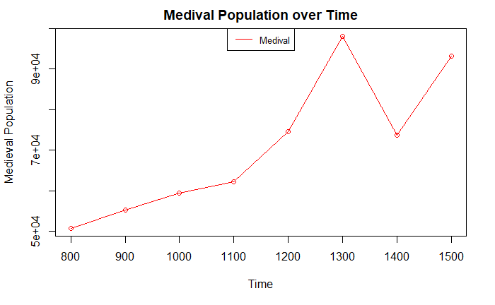

```r
legend("top", legend=c("Medival"),col=c("red"), lty = 1:2, cex=0.8)
```

```r
plot(x = aggEarlyModern$Category, y = aggEarlyModern$x, type = "o", col="green", xlab = "Early Modern Population", ylab = "Time", lty = 2, main = "Early Modern population over Time")
par(new = TRUE)
```

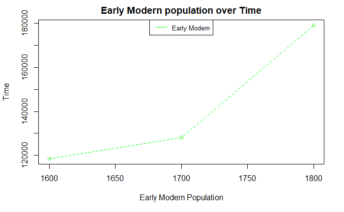

```r
legend("top", legend=c("Early Modern"),col=c("green"), lty = 1:2, cex=0.8)
```

# North Africa and Europe?

Can you construct comparative graphs of population in North Africa and Europe (similar to what you did with the Morris dataset). Here you will need to sum up population!

```r
#North Africa and Europe?
unique_countries <- unique(bagdad_london_finalRestat$country)
Europevector <- c("Austria", "Ireland", "Belgium", "Czech rep.", "Denmark", "Finland", "France", "Germany", "Hungary", "Italy", "Netherlands", "Norway", "Poland", "Portugal", "Slovakia", "Spain", "Sweden", "UK", "Switzerland", "Greece", "Turkey", "Yugoslavia", "Albania", "Bulgaria", "Rumenia", "Luxemburg", "Malta")
NorthAfricavector <- c("Morocco", "Tunesia", "Lybia", "Egypt", "Syria")
Europe.bagdad <- bagdad_london_finalRestat[bagdad_london_finalRestat$country %in% Europevector, ]
NorthAfrica.bagdad <- bagdad_london_finalRestat[bagdad_london_finalRestat$country %in% NorthAfricavector, ]
```

```r
data.frame.europe <- data.frame("year" = Europe.bagdad$year, "country" = Europe.bagdad$country, "pop" = Europe.bagdad$total_pop_country)
data.frame.Africa <- data.frame("year" = NorthAfrica.bagdad$year, "country" = NorthAfrica.bagdad$country, "pop" = NorthAfrica.bagdad$total_pop_country)
uniqueAfrica = unique(data.frame.Africa[c("year", "country", "pop")])
aggAfrica = aggregate(uniqueAfrica$pop, by=list(Category=uniqueAfrica$year), FUN=sum)
data.frame.Europe <- data.frame("year" = Europe.bagdad$year, "country" = Europe.bagdad$country, "pop" = Europe.bagdad$total_pop_country)
uniqueEurope = unique(data.frame.Europe[c("year", "country", "pop")])
aggEurope = aggregate(uniqueEurope$pop, by=list(Category=uniqueEurope$year), FUN=sum)
plot(x = aggAfrica$Category, y = aggAfrica$x, type = "l", col="red", ylab = "Population per country", xlab = "Time", main = "Comparative graph of Europe's and North Africa's population")
par(new = TRUE)
```

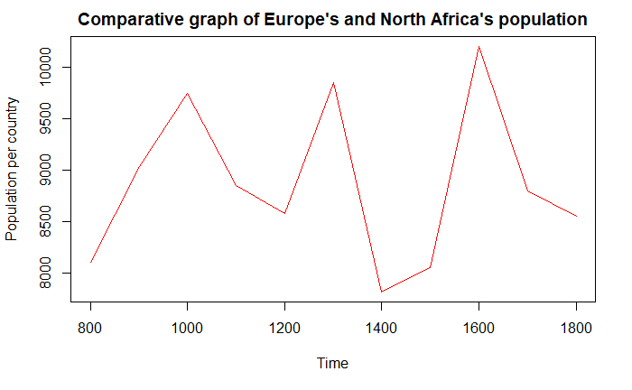

```r
plot(x = aggEurope$Category, y = aggEurope$x, type = "l", col="green", axes = FALSE, xlab = " ", ylab = " ", lty = 2)
legend("top", legend=c("North Africa", "Europe"),col=c("red", "green"), lty = 1:2, cex=0.8)
```

[output not shown]

```r
habsburg <- bagdad_london_finalRestat[bagdad_london_finalRestat$year>=1500, c('city', 'country', 'year')]

exclude_countries <- c("Belgium", "Denmark", "Finland", "France", "Ireland", "Netherlands", "Norway", "Poland", "Portugal", "Spain", "Sweden", "UK", "Switzerland", "Greece", "Turkey", "Lebanon", "Israel", "Syria", "Iraq", "Egypt", "Lybia", "Tunesia", "Algeria", "Morocco", "Yemen", "Saudi Arabia","Oman", "Cyprus", "Luxemburg", "Malta", "Bulgaria")

habsburg <- habsburg[!(habsburg$country %in% exclude_countries), ]


library("dplyr")
habsburg %>% count(habsburg$year)
```

[output not shown]

Roxana’s fugly “I don’t know so I am just tipping” solution to the largest cities in Islamdom per period

```r
#Largest cities of Islamdom for each reported period
head(bagdad_london_finalRestat)
```

| indicator | city | country | year | arab_peninsula | latitude | longitude | citypop_le10 | citypop_le5 | sea | river | hub_3rr | rom_road_nohub | caravan_hub | caravan_nohub | elevation_m | rugg10 | bishop | archbishop | capital | university | muslim | me_na | muslim_holy_city | plundered | soilquality | commune | ecozones | free_prince_dls | total_pop_country | … |
| --- | --- | --- | --- | --- | --- | --- | --- | --- | --- | --- | --- | --- | --- | --- | --- | --- | --- | --- | --- | --- | --- | --- | --- | --- | --- | --- | --- | --- | --- | --- |
| 1 | Graz | Austria | 800 | 0 | 47.067 | 15.450 | 0 | 0 | 0 | 1 | 0 | 1 | 0 | 0 | 366 | 103.620 | 0 | 0 | 0 | 0 | 0 | 0 | 0 | 0 | 0.414 | 0 | 6 | 0 | 500 | … |
| 2 | Innsbruck | Austria | 800 | 0 | 47.267 | 11.400 | 0 | 0 | 0 | 1 | 1 | 0 | 0 | 0 | 562 | 559.450 | 0 | 0 | 0 | 0 | 0 | 0 | 0 | 0 | 0.020 | 0 | 6 | 0 | 500 | … |
| 3 | Klagenfurt | Austria | 800 | 0 | 46.625 | 14.305 | 0 | 0 | 0 | 1 | 0 | 0 | 0 | 0 | 441 | 99.808 | 0 | 0 | 0 | 0 | 0 | 0 | 0 | 0 | 0.384 | 0 | 6 | 0 | 500 | … |
| 4 | Linz | Austria | 800 | 0 | 48.300 | 14.300 | 0 | 0 | 0 | 1 | 0 | 1 | 0 | 0 | 258 | 141.270 | 0 | 0 | 0 | 0 | 0 | 0 | 0 | 0 | 0.660 | 0 | 4 | 0 | 500 | … |
| 5 | Salzburg | Austria | 800 | 0 | 47.800 | 13.033 | 0 | 0 | 0 | 1 | 1 | 0 | 0 | 0 | 427 | 208.720 | 0 | 1 | 0 | 0 | 0 | 0 | 0 | 0 | 0.326 | 0 | 6 | 0 | 500 | … |
| 6 | Wien (Vienna) | Austria | 800 | 0 | 48.200 | 16.367 | 0 | 0 | 0 | 1 | 1 | 0 | 0 | 0 | 170 | 51.159 | 0 | 0 | 0 | 0 | 0 | 0 | 0 | 0 | 0.978 | 0 | 4 | 0 | 500 | … |

```r
acht<-subset(bagdad_london_finalRestat, bagdad_london_finalRestat$year == 800)
neun<-subset(bagdad_london_finalRestat, bagdad_london_finalRestat$year == 900)
t<-subset(bagdad_london_finalRestat, bagdad_london_finalRestat$year == 1000)
teins<-subset(bagdad_london_finalRestat, bagdad_london_finalRestat$year == 1100)
tzwei<-subset(bagdad_london_finalRestat, bagdad_london_finalRestat$year == 1200)
tdrei<-subset(bagdad_london_finalRestat, bagdad_london_finalRestat$year == 1300)
tvier<-subset(bagdad_london_finalRestat, bagdad_london_finalRestat$year == 1400)
tfunf<-subset(bagdad_london_finalRestat, bagdad_london_finalRestat$year == 1500)
tsechs<-subset(bagdad_london_finalRestat, bagdad_london_finalRestat$year == 1600)
tsieben<-subset(bagdad_london_finalRestat, bagdad_london_finalRestat$year == 1700)
tacht<-subset(bagdad_london_finalRestat, bagdad_london_finalRestat$year == 1800)
#brauch ich auch nicht: Muslimcit<-subset(bagdad_london_finalRestat, bagdad_london_finalRestat$muslim == 1)
achtmuslcit<-subset(acht, acht$muslim==1)
max(achtmuslcit$citypop_le10)
```

```
[1] 350
```

```r
neunmuslcit<-subset(neun, neun$muslim==1)
max(neunmuslcit$citypop_le10)
```

```
[1] 450
```

```r
tmuslcit<-subset(t, t$muslim==1)
max(tmuslcit$citypop_le10)
```

```
[1] 300
```

```r
teinsmuslcit<-subset(teins, teins$muslim==1)
max(teinsmuslcit$citypop_le10)
```

```
[1] 250
```

```r
tzweimuslcit<-subset(tzwei, tzwei$muslim==1)
max(tzweimuslcit$citypop_le10)
```

```
[1] 200
```

```r
tdreimuslcit<-subset(tdrei, tdrei$muslim==1)
max(tdreimuslcit$citypop_le10)
```

```
[1] 220
```

```r
tviermuslcit<-subset(tvier, tvier$muslim==1)
max(tviermuslcit$citypop_le10)
```

```
[1] 250
```

```r
tfunfmuslcit<-subset(tfunf, tfunf$muslim==1)
max(tfunfmuslcit$citypop_le10)
```

```
[1] 280
```

```r
tsechsmuslcit<-subset(tsechs, tsechs$muslim==1)
max(tsechsmuslcit$citypop_le10)
```

```
[1] 700
```

```r
tsiebenmuslcit<-subset(tsieben, tsieben$muslim==1)
max(tsiebenmuslcit$citypop_le10)
```

```
[1] 700
```

```r
tachtmuslcit<-subset(tacht, tacht$muslim==1)
max(tachtmuslcit$citypop_le10)
```

```
[1] 500
```

```r
library(dplyr)
cityacht<-filter(achtmuslcit, achtmuslcit$citypop_le10>=350)
cityacht
```

| indicator | city | country | year | arab_peninsula | latitude | longitude | citypop_le10 | citypop_le5 | sea | river | hub_3rr | rom_road_nohub | caravan_hub | caravan_nohub | elevation_m | rugg10 | bishop | archbishop | capital | university | muslim | me_na | muslim_holy_city | plundered | soilquality | commune | ecozones | free_prince_dls | total_pop_country | … |
| --- | --- | --- | --- | --- | --- | --- | --- | --- | --- | --- | --- | --- | --- | --- | --- | --- | --- | --- | --- | --- | --- | --- | --- | --- | --- | --- | --- | --- | --- | --- |
| 619 | Baghdad (Bagdad) | Iraq | 800 | 0 | 33.339 | 44.394 | 350 | 350 | 0 | 1 | 0 | 0 | 1 | 0 | 24 | 4.0798 | 1 | 0 | 1 | 0 | 1 | 1 | 0 | 0 | 0.022 | 0 | 2 | 0 | 2500 | … |

```r
cityneun<-filter(neunmuslcit, neunmuslcit$citypop_le10>=450)
cityneun
```

| indicator | city | country | year | arab_peninsula | latitude | longitude | citypop_le10 | citypop_le5 | sea | river | hub_3rr | rom_road_nohub | caravan_hub | caravan_nohub | elevation_m | rugg10 | bishop | archbishop | capital | university | muslim | me_na | muslim_holy_city | plundered | soilquality | commune | ecozones | free_prince_dls | total_pop_country | … |
| --- | --- | --- | --- | --- | --- | --- | --- | --- | --- | --- | --- | --- | --- | --- | --- | --- | --- | --- | --- | --- | --- | --- | --- | --- | --- | --- | --- | --- | --- | --- |
| 619 | Baghdad (Bagdad) | Iraq | 900 | 0 | 33.339 | 44.394 | 450 | 450 | 0 | 1 | 0 | 0 | 1 | 0 | 24 | 4.0798 | 1 | 0 | 1 | 0 | 1 | 1 | 0 | 0 | 0.022 | 0 | 2 | 0 | 2250 | … |

```r
citytausend<-filter(tmuslcit, tmuslcit$citypop_le10>=300)
citytausend
```

| indicator | city | country | year | arab_peninsula | latitude | longitude | citypop_le10 | citypop_le5 | sea | river | hub_3rr | rom_road_nohub | caravan_hub | caravan_nohub | elevation_m | rugg10 | bishop | archbishop | capital | university | muslim | me_na | muslim_holy_city | plundered | soilquality | commune | ecozones | free_prince_dls | total_pop_country | … |
| --- | --- | --- | --- | --- | --- | --- | --- | --- | --- | --- | --- | --- | --- | --- | --- | --- | --- | --- | --- | --- | --- | --- | --- | --- | --- | --- | --- | --- | --- | --- |
| 619 | Baghdad (Bagdad) | Iraq | 1000 | 0 | 33.339 | 44.394 | 300 | 300 | 0 | 1 | 0 | 0 | 1 | 0 | 24 | 4.0798 | 1 | 0 | 1 | 0 | 1 | 1 | 0 | 0 | 0.022 | 0 | 2 | 0 | 2000 | … |

```r
citytausendein<-filter(teinsmuslcit, teinsmuslcit$citypop_le10>=250)
citytausendein
```

| indicator | city | country | year | arab_peninsula | latitude | longitude | citypop_le10 | citypop_le5 | sea | river | hub_3rr | rom_road_nohub | caravan_hub | caravan_nohub | elevation_m | rugg10 | bishop | archbishop | capital | university | muslim | me_na | muslim_holy_city | plundered | soilquality | commune | ecozones | free_prince_dls | total_pop_country | … |
| --- | --- | --- | --- | --- | --- | --- | --- | --- | --- | --- | --- | --- | --- | --- | --- | --- | --- | --- | --- | --- | --- | --- | --- | --- | --- | --- | --- | --- | --- | --- |
| 619 | Baghdad (Bagdad) | Iraq | 1100 | 0 | 33.339 | 44.394 | 250 | 250 | 0 | 1 | 0 | 0 | 1 | 0 | 24 | 4.0798 | 1 | 0 | 1 | 0 | 1 | 1 | 0 | 0 | 0.022 | 0 | 2 | 0 | 1750 | … |

```r
citytausendzwei<-filter(tzweimuslcit, tzweimuslcit$citypop_le10>=200)
citytausendzwei
```

| indicator | city | country | year | arab_peninsula | latitude | longitude | citypop_le10 | citypop_le5 | sea | river | hub_3rr | rom_road_nohub | caravan_hub | caravan_nohub | elevation_m | rugg10 | bishop | archbishop | capital | university | muslim | me_na | muslim_holy_city | plundered | soilquality | commune | ecozones | free_prince_dls | total_pop_country | … |
| --- | --- | --- | --- | --- | --- | --- | --- | --- | --- | --- | --- | --- | --- | --- | --- | --- | --- | --- | --- | --- | --- | --- | --- | --- | --- | --- | --- | --- | --- | --- |
| 619 | Baghdad (Bagdad) | Iraq | 1200 | 0 | 33.339 | 44.394 | 200 | 200 | 0 | 1 | 0 | 0 | 1 | 0 | 24 | 4.0798 | 1 | 0 | 1 | 0 | 1 | 1 | 0 | 0 | 0.022 | 0 | 2 | 0 | 1500 | … |
| 624 | Fustat (Cairo, ~Heliopolis, Al-Kahira) | Egypt | 1200 | 0 | 30.050 | 31.250 | 200 | 200 | 0 | 1 | 0 | 1 | 1 | 0 | 30 | 37.7050 | 1 | 0 | 1 | 1 | 1 | 1 | 0 | 0 | 0.010 | 0 | 1 | 0 | 4000 | … |

```r
citytausenddrei<-filter(tdreimuslcit, tdreimuslcit$citypop_le10>=220)
citytausenddrei
```

| indicator | city | country | year | arab_peninsula | latitude | longitude | citypop_le10 | citypop_le5 | sea | river | hub_3rr | rom_road_nohub | caravan_hub | caravan_nohub | elevation_m | rugg10 | bishop | archbishop | capital | university | muslim | me_na | muslim_holy_city | plundered | soilquality | commune | ecozones | free_prince_dls | total_pop_country | … |
| --- | --- | --- | --- | --- | --- | --- | --- | --- | --- | --- | --- | --- | --- | --- | --- | --- | --- | --- | --- | --- | --- | --- | --- | --- | --- | --- | --- | --- | --- | --- |
| 624 | Fustat (Cairo, ~Heliopolis, Al-Kahira) | Egypt | 1300 | 0 | 30.05 | 31.25 | 220 | 220 | 0 | 1 | 0 | 1 | 1 | 0 | 30 | 37.705 | 1 | 0 | 1 | 1 | 1 | 1 | 0 | 0 | 0.01 | 0 | 1 | 0 | 4800 | … |

```r
citytausendvier<-filter(tviermuslcit, tviermuslcit$citypop_le10>=250)
citytausendfunf<-filter(tfunfmuslcit, tfunfmuslcit$citypop_le10>=280)
citytausendsechs<-filter(tsechsmuslcit, tsechsmuslcit$citypop_le10>=700)
citytausendsieben<-filter(tsiebenmuslcit, tsiebenmuslcit$citypop_le10>=700)
citytausendacht<-filter(tachtmuslcit, tachtmuslcit$citypop_le10>=500)
citytausendacht
```

| indicator | city | country | year | arab_peninsula | latitude | longitude | citypop_le10 | citypop_le5 | sea | river | hub_3rr | rom_road_nohub | caravan_hub | caravan_nohub | elevation_m | rugg10 | bishop | archbishop | capital | university | muslim | me_na | muslim_holy_city | plundered | soilquality | commune | ecozones | free_prince_dls | total_pop_country | … |
| --- | --- | --- | --- | --- | --- | --- | --- | --- | --- | --- | --- | --- | --- | --- | --- | --- | --- | --- | --- | --- | --- | --- | --- | --- | --- | --- | --- | --- | --- | --- |
| 598 | Constantinople (Istanbul, Byzantium, Konstantinopel) | Turkey | 1800 | 0 | 41.017 | 28.967 | 500 | 500 | 1 | 1 | 1 | 0 | 0 | 1 | 1 | 37.054 | 0 | 1 | 1 | 0 | 1 | 1 | 0 | 0 | 0.991 | 0 | 5 | 0 | 9600 | … |

```r
acht
```

| indicator | city | country | year | arab_peninsula | latitude | longitude | citypop_le10 | citypop_le5 | sea | river | hub_3rr | rom_road_nohub | caravan_hub | caravan_nohub | elevation_m | rugg10 | bishop | archbishop | capital | university | muslim | me_na | muslim_holy_city | plundered | soilquality | commune | ecozones | free_prince_dls | total_pop_country | … |
| --- | --- | --- | --- | --- | --- | --- | --- | --- | --- | --- | --- | --- | --- | --- | --- | --- | --- | --- | --- | --- | --- | --- | --- | --- | --- | --- | --- | --- | --- | --- |
| 1 | Graz | Austria | 800 | 0 | 47.067 | 15.450 | 0 | 0 | 0 | 1 | 0 | 1 | 0 | 0 | 366 | 103.62000 | 0 | 0 | 0 | 0 | 0 | 0 | 0 | 0 | 0.4140000 | 0 | 6 | 0 | 500 | … |
| 2 | Innsbruck | Austria | 800 | 0 | 47.267 | 11.400 | 0 | 0 | 0 | 1 | 1 | 0 | 0 | 0 | 562 | 559.45001 | 0 | 0 | 0 | 0 | 0 | 0 | 0 | 0 | 0.0200000 | 0 | 6 | 0 | 500 | … |
| 3 | Klagenfurt | Austria | 800 | 0 | 46.625 | 14.305 | 0 | 0 | 0 | 1 | 0 | 0 | 0 | 0 | 441 | 99.80800 | 0 | 0 | 0 | 0 | 0 | 0 | 0 | 0 | 0.3840000 | 0 | 6 | 0 | 500 | … |
| 4 | Linz | Austria | 800 | 0 | 48.300 | 14.300 | 0 | 0 | 0 | 1 | 0 | 1 | 0 | 0 | 258 | 141.27000 | 0 | 0 | 0 | 0 | 0 | 0 | 0 | 0 | 0.6600000 | 0 | 4 | 0 | 500 | … |
| 5 | Salzburg | Austria | 800 | 0 | 47.800 | 13.033 | 0 | 0 | 0 | 1 | 1 | 0 | 0 | 0 | 427 | 208.72000 | 0 | 1 | 0 | 0 | 0 | 0 | 0 | 0 | 0.3260000 | 0 | 6 | 0 | 500 | … |
| 6 | Wien (Vienna) | Austria | 800 | 0 | 48.200 | 16.367 | 0 | 0 | 0 | 1 | 1 | 0 | 0 | 0 | 170 | 51.15900 | 0 | 0 | 0 | 0 | 0 | 0 | 0 | 0 | 0.9780000 | 0 | 4 | 0 | 500 | … |
| 7 | Aalst (Alost) | Belgium | 800 | 0 | 50.933 | 4.033 | 0 | 0 | 0 | 1 | 0 | 0 | 0 | 0 | 17 | 15.28100 | 0 | 0 | 0 | 0 | 0 | 0 | 0 | 0 | 0.7180000 | 0 | 4 | 0 | 300 | … |
| 8 | Antwerpen (Anvers, Antwerp) | Belgium | 800 | 0 | 51.217 | 4.417 | 0 | 0 | 1 | 1 | 0 | 0 | 0 | 0 | 3 | 4.11510 | 0 | 0 | 0 | 0 | 0 | 0 | 0 | 0 | 0.5630000 | 0 | 4 | 0 | 300 | … |
| 9 | Brugge (bruges) | Belgium | 800 | 0 | 51.217 | 3.233 | 0 | 0 | 1 | 1 | 0 | 0 | 0 | 0 | 2 | 3.16190 | 0 | 0 | 0 | 0 | 0 | 0 | 0 | 0 | 0.7050000 | 0 | 4 | 0 | 300 | … |
| 10 | Bruxelles (brussels) | Belgium | 800 | 0 | 50.833 | 4.333 | 0 | 0 | 0 | 0 | 0 | 1 | 0 | 0 | 62 | 29.41600 | 0 | 0 | 0 | 0 | 0 | 0 | 0 | 0 | 0.7180000 | 0 | 4 | 0 | 300 | … |

[output cut: 783 more lines]

```r
achtmuslcit
```

| indicator | city | country | year | arab_peninsula | latitude | longitude | citypop_le10 | citypop_le5 | sea | river | hub_3rr | rom_road_nohub | caravan_hub | caravan_nohub | elevation_m | rugg10 | bishop | archbishop | capital | university | muslim | me_na | muslim_holy_city | plundered | soilquality | commune | ecozones | free_prince_dls | total_pop_country | … |
| --- | --- | --- | --- | --- | --- | --- | --- | --- | --- | --- | --- | --- | --- | --- | --- | --- | --- | --- | --- | --- | --- | --- | --- | --- | --- | --- | --- | --- | --- | --- |
| 406 | Braga | Portugal | 800 | 0 | 41.550 | -8.433 | 0 | 0 | 0 | 1 | 1 | 0 | 0 | 0 | 164 | 114.2200 | 0 | 0 | 0 | 0 | 1 | 0 | 0 | 0 | 0.2180000 | 0 | 6 | 0 | 400 | … |
| 407 | Coimbra Kulumriyya) | Portugal | 800 | 0 | 40.200 | -8.417 | 0 | 0 | 0 | 1 | 0 | 1 | 0 | 0 | 17 | 107.1000 | 0 | 0 | 0 | 0 | 1 | 0 | 0 | 0 | 0.3380000 | 0 | 3 | 0 | 400 | … |
| 408 | Elvas | Portugal | 800 | 0 | 38.883 | -7.167 | 0 | 0 | 0 | 0 | 0 | 0 | 0 | 0 | 272 | 80.5600 | 0 | 0 | 0 | 0 | 1 | 0 | 0 | 0 | 0.8780000 | 0 | 4 | 0 | 400 | … |
| 409 | Evora | Portugal | 800 | 0 | 38.567 | -7.900 | 0 | 0 | 0 | 0 | 0 | 1 | 0 | 0 | 261 | 31.7390 | 0 | 0 | 0 | 0 | 1 | 0 | 0 | 0 | 0.7430000 | 0 | 3 | 0 | 400 | … |
| 410 | Lisboa (Lisbon, Lissabon, Al Ushbuna) | Portugal | 800 | 0 | 38.717 | -9.133 | 15 | 15 | 1 | 1 | 1 | 0 | 0 | 0 | 63 | 49.9310 | 0 | 0 | 0 | 0 | 1 | 0 | 0 | 0 | 0.9770000 | 0 | 4 | 0 | 400 | … |
| 413 | Santarem (Shantarim) | Portugal | 800 | 0 | 39.233 | -8.683 | 0 | 0 | 0 | 1 | 1 | 0 | 0 | 0 | 133 | 31.4450 | 0 | 0 | 0 | 0 | 1 | 0 | 0 | 0 | 0.9540000 | 0 | 3 | 0 | 400 | … |
| 417 | Alcala-de-Henares | Spain | 800 | 0 | 40.483 | -3.367 | 0 | 0 | 0 | 1 | 0 | 1 | 0 | 0 | 578 | 61.0270 | 0 | 0 | 0 | 0 | 1 | 0 | 0 | 0 | 0.6080000 | 0 | 4 | 0 | 3750 | … |
| 418 | Alcala-la-Real | Spain | 800 | 0 | 37.467 | -3.933 | 0 | 0 | 0 | 0 | 0 | 0 | 0 | 0 | 853 | 147.0600 | 0 | 0 | 0 | 0 | 1 | 0 | 0 | 0 | 0.8580000 | 0 | 4 | 0 | 3750 | … |
| 419 | Alcazar de San Juan | Spain | 800 | 0 | 39.400 | -3.200 | 0 | 0 | 0 | 0 | 0 | 1 | 0 | 0 | 655 | 28.2700 | 0 | 0 | 0 | 0 | 1 | 0 | 0 | 0 | 0.6210000 | 0 | 4 | 0 | 3750 | … |
| 420 | Alcoy | Spain | 800 | 0 | 38.700 | -0.467 | 0 | 0 | 0 | 0 | 0 | 0 | 0 | 0 | 531 | 224.8100 | 0 | 0 | 0 | 0 | 1 | 0 | 0 | 0 | 0.8820000 | 0 | 4 | 0 | 3750 | … |

[output cut: 166 more lines]

# Subsetting data

## Introducing North Africa and Europe

Filter for Countries with unique save it as a vector in a variable and create csv with country plus continents. Than merge this table with the original datafile in R (variable). R can merge it automatically. (find code)

## Introducing Austrian-Hungarian Empire

Filter countries and assign oberservation “Austrian…” in a variable called Dynastie. Include countries of the empire and reduce the dataset to this countries. Exclude years before the empire existed. Exclude cities that were never part of the empire. Define cities that were part of the empire from to.